# Trading and investment account summary

# For 2020-08-14

Summary text: The equity value of my live trading portfolio changed by -0.27 % (US$ -88.86 ) from US$ 33177.05 to US$ 33088.19 today ( 2020-08-14 ). The trading proceeds in my live account were US$ 14.8300000000002 . The book proceeds in my portfolio changed from US$ 1980.26 to US$ 1876.57

## Portfolio

The below table shows the current positions in the live account as well as their current and total performance. “book_proceed” indicates the unrealized profit in that position.

| symbol | close | closePerc | Total_Change_close | entry_price | position | position_size | entry_position | totalPerc | book_proceed | sector |
| --- | --- | --- | --- | --- | --- | --- | --- | --- | --- | --- |
| BRK.B | 210.98 | -0.42 | -45 | 195.40 | 50 | 10549.00 | 9770.15 | 7.38 | 778.85 | Finance |
| KWEB | 65.73 | -1.88 | -189 | 67.38 | 150 | 9859.50 | 10107.04 | -2.51 | -247.54 | Miscellaneous |
| SEAS | 19.00 | 2.54 | -188 | 18.26 | -400 | -7600.00 | -7305.12 | -3.88 | -294.88 | Consumer Services |
| EZA | 37.43 | 0.4 | -30 | 38.54 | -200 | -7486.00 | -7708.00 | 2.97 | 222 | Miscellaneous |
| HD | 280.54 | -0.42 | -17.7 | 275.84 | 15 | 4208.10 | 4137.65 | 1.67 | 70.45 | Retail Trade |
| CAKE | 27.17 | 0.63 | 25.5 | 23.15 | 150 | 4075.50 | 3472.28 | 14.8 | 603.22 | Consumer Services |
| JWN | 17.12 | 2.09 | 78.75 | 15.03 | 225 | 3852.00 | 3382.48 | 12.19 | 469.52 | Retail Trade |
| SQ | 141.91 | -0.87 | -31.25 | 141.33 | 25 | 3547.75 | 3533.37 | 0.41 | 14.38 | Technology Services |
| TSLA | 1651.50 | 1.9 | 61.58 | 1405.56 | 2 | 3303.00 | 2811.11 | 14.89 | 491.89 | Consumer Durables |
| INDA | 32.97 | -0.2 | -6.5 | 33.05 | 100 | 3296.50 | 3304.99 | -0.26 | -8.49 | Miscellaneous |
| MIK | 8.36 | 2.39 | 68.25 | 8.51 | 350 | 2926.00 | 2979.42 | -1.83 | -53.42 | Retail Trade |
| SLV | 24.57 | -3.38 | -94.6 | 22.13 | 110 | 2702.70 | 2434.80 | 9.91 | 267.9 | Miscellaneous |
| TPR | 15.93 | 3.17 | 73.5 | 14.67 | 150 | 2389.50 | 2201.24 | 7.88 | 188.26 | Retail Trade |
| WPM | 50.56 | -0.51 | -10.4 | 55.66 | 40 | 2022.40 | 2226.53 | -10.09 | -204.13 | Non-Energy Minerals |
| V | 196.63 | -0.48 | -9.5 | 194.66 | 10 | 1966.30 | 1946.64 | 1 | 19.66 | Finance |
| LMND | 63.22 | 6.72 | 119.4 | 78.07 | 30 | 1896.60 | 2342.14 | -23.49 | -445.54 | Finance |
| GSX | 89.25 | -10.75 | -215 | 86.60 | 20 | 1785.00 | 1731.94 | 2.97 | 53.06 | Technology Services |
| RVLV | 22.30 | -6.3 | -112.5 | 18.07 | 75 | 1672.50 | 1354.99 | 18.98 | 317.51 | Retail Trade |
| SWKS | 146.11 | -1.32 | -19.6 | 131.85 | 10 | 1461.10 | 1318.50 | 9.76 | 142.6 | Electronic Technology |
| CAT | 139.97 | -0.49 | -6.9 | 142.04 | 10 | 1399.70 | 1420.40 | -1.48 | -20.7 | Producer Manufacturing |
| LUV | 34.90 | 0.52 | 7.2 | 36.08 | 40 | 1396.00 | 1443.30 | -3.39 | -47.3 | Transportation |
| XOM | 43.21 | 0.45 | 6.24 | 44.00 | 32 | 1382.72 | 1408.10 | -1.84 | -25.38 | Energy Minerals |
| EPHE | 27.42 | 0.7 | -9.5 | 25.67 | -50 | -1371.00 | -1283.40 | -6.39 | -87.6 | Miscellaneous |
| DKNG | 33.90 | -5.96 | -86 | 33.47 | 40 | 1356.00 | 1338.67 | 1.28 | 17.34 | Technology Services |
| PPLT | 89.03 | -1.86 | -25.35 | 89.44 | 15 | 1335.45 | 1341.55 | -0.46 | -6.1 | Miscellaneous |
| UNM | 19.05 | 1.03 | 13.65 | 19.50 | 70 | 1333.85 | 1365.00 | -2.34 | -31.15 | Finance |
| CSCO | 42.50 | -0.51 | -6.6 | 43.62 | 30 | 1275.00 | 1308.75 | -2.65 | -33.75 | Technology Services |
| MGM | 21.82 | 2.25 | 24 | 21.35 | 50 | 1091.00 | 1067.50 | 2.15 | 23.5 | Consumer Services |
| NOVA | 24.29 | -13.8 | -171.16 | 24.33 | 44 | 1068.76 | 1070.52 | -0.16 | -1.76 | Distribution Services |
| UPWK | 14.79 | -1.53 | -16.33 | 14.48 | 71 | 1050.09 | 1028.24 | 2.08 | 21.85 | Technology Services |
| PALL | 200.36 | -2.22 | -22.7 | 219.68 | 5 | 1001.80 | 1098.40 | -9.64 | -96.6 | Miscellaneous |
| BIDU | 116.73 | -6.35 | -63.36 | 115.72 | 8 | 933.84 | 925.76 | 0.87 | 8.08 | Technology Services |
| IAU | 18.55 | -0.38 | -3.5 | 19.30 | 50 | 927.50 | 965.00 | -4.04 | -37.5 | Miscellaneous |
| IQ | 19.25 | -11.21 | -89.91 | 18.34 | 37 | 712.25 | 678.58 | 4.73 | 33.67 | Technology Services |
| PRU | 70.61 | 1.55 | 10.8 | 71.74 | 10 | 706.10 | 717.40 | -1.6 | -11.3 | Finance |
| ILMN | 347.55 | -1.67 | -11.84 | 346.12 | 2 | 695.10 | 692.24 | 0.41 | 2.86 | Health Technology |
| GOLD | 27.00 | -0.52 | -3.5 | 27.48 | 25 | 675.00 | 686.88 | -1.76 | -11.88 | Non-Energy Minerals |
| FIZZ | 64.60 | 0.47 | 3 | 68.20 | 10 | 646.00 | 682.00 | -5.57 | -36 | Consumer Non-Durables |
| GDX | 40.33 | -0.71 | -4.35 | 43.89 | 15 | 604.95 | 658.39 | -8.83 | -53.44 | Miscellaneous |
| CRUS | 60.39 | -1.31 | -8 | 71.60 | 10 | 603.90 | 716.05 | -18.57 | -112.15 | Electronic Technology |
| NFLX | 482.57 | 0.28 | 1.34 | 486.00 | 1 | 482.57 | 486.00 | -0.71 | -3.43 | Consumer Services |

| symbol | close | closePerc | Total_Change_close | entry_price | position | position_size | entry_position | totalPerc | book_proceed | sector |
| --- | --- | --- | --- | --- | --- | --- | --- | --- | --- | --- |
| Summary | NA | NA | -1004.84 | NA | 2737 | 98648.03 | NA | 1.9 | 1876.565 | NA |

[interactive chart not shown]

The performance of my live stock portfolio/trading account vs. my paper trading account and the benchmark ‘SPY’, the US large cap stock market index ETF in percent since June 09 2020.

[interactive chart not shown]

This plot shows a summary of the trading activity on that day. Above 0 is a gain, below is a loss. TRUE indicated live trading account, FALSE is paper trading. A buy side trade is a closed short sale trade and sell side trade is a closed long trade.

[interactive chart not shown]

My current portfolio sorted by sectors. The plot reads clock-wise. Positions below 0 are short positions. Clicking a slice of the pie chart directs to marketwatch.com for further information.

[interactive chart not shown]

These two plots indicate the composition of my portfolio and the change of it over the past week.

[interactive chart not shown]

The inner circle is Monday, the outer circle is Friday.

[interactive chart not shown]

The colors in this plot indicate the daily percentage change of each stock in my portfolio.

[interactive chart not shown]

I classified the stocks in my portfolio by sector. The area represents the size of the position in the portfolio. Long postions

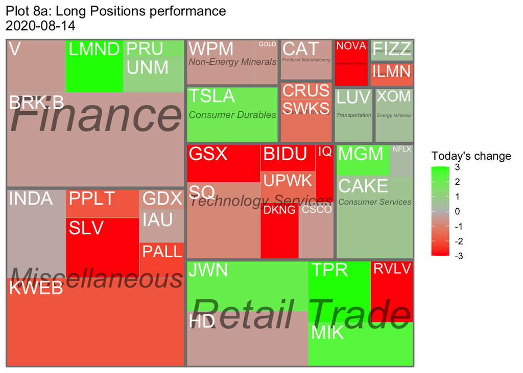

Short postions

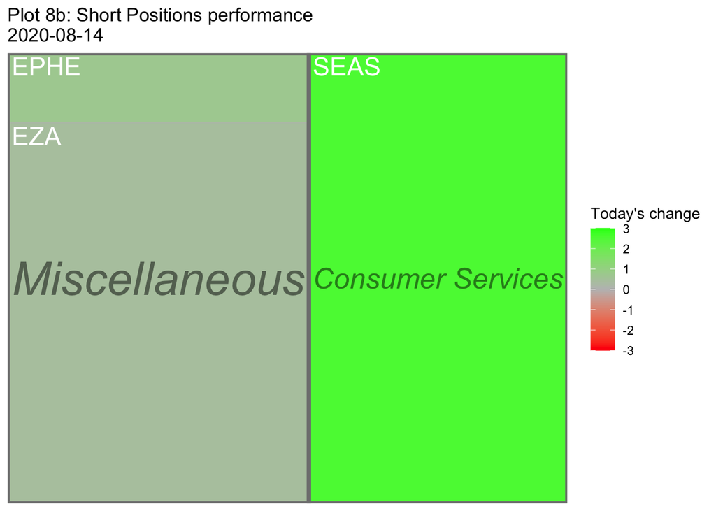

S&P 500 stocks colored by last day performance.

Outliers skew the colors, making the other stocks look pale. I restricted the colors to max of 3 and -3% change. Every stock having higher or lower than 3% change has the same color.

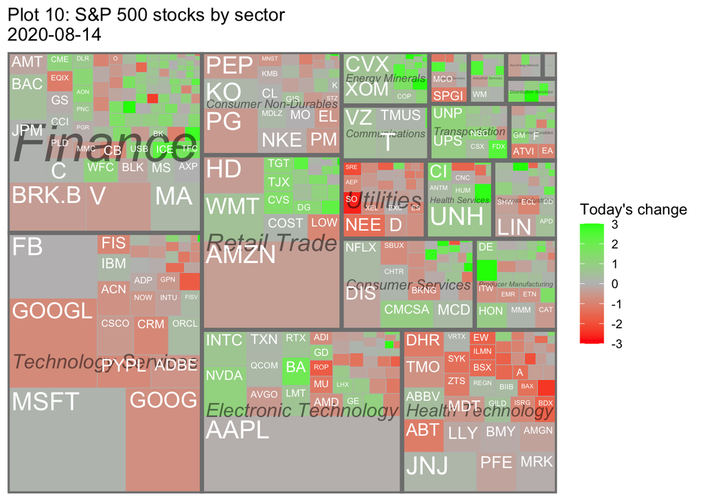

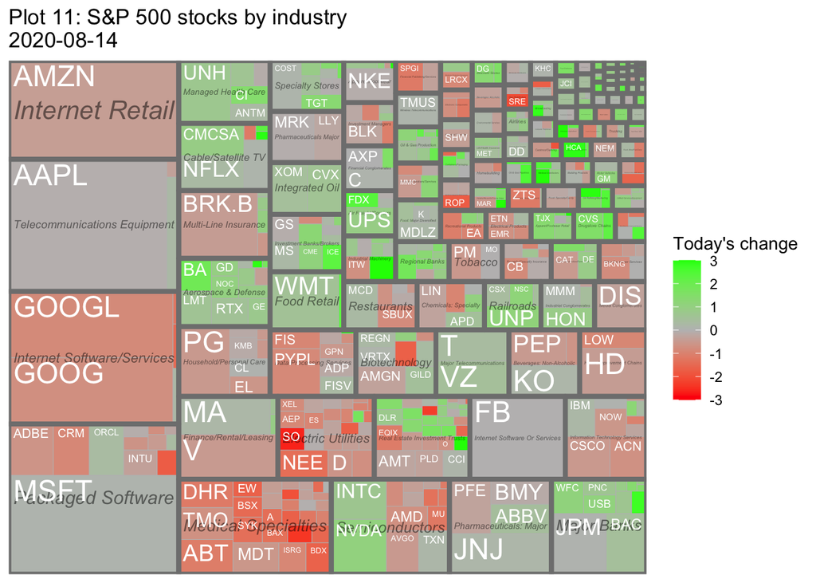